# Homework 2

## Step 3: Build a third linear model

- Convert the origin variable to a factor
- Use the lm() function to perform multiple linear regression with mpg as the response and all other variables except name as predictors
- Use the summary() function to print the results
- Which predictors appear to have a statistically significant relationship to the response?

Your commentary here: The ones with statical significance seem to be weight, year, origins, and displacement.

```r
# your code here


df$origin <- factor(df$origin)
levels(df$origin) <- c("American","European","Japanese")

lm4 <-  lm(mpg~(cylinders+displacement+horsepower+weight+acceleration+year+origin),data=df)
summary(lm4)
```

```
##
## Call:
## lm(formula = mpg ~ (cylinders + displacement + horsepower + weight +
##     acceleration + year + origin), data = df)
##
## Residuals:
##     Min      1Q  Median      3Q     Max
## -9.0095 -2.0785 -0.0982  1.9856 13.3608
##
## Coefficients:
##                  Estimate Std. Error t value Pr(>|t|)
## (Intercept)    -1.795e+01  4.677e+00  -3.839 0.000145 ***
## cylinders      -4.897e-01  3.212e-01  -1.524 0.128215
## displacement    2.398e-02  7.653e-03   3.133 0.001863 **
## horsepower     -1.818e-02  1.371e-02  -1.326 0.185488
## weight         -6.710e-03  6.551e-04 -10.243  < 2e-16 ***
## acceleration    7.910e-02  9.822e-02   0.805 0.421101
## year            7.770e-01  5.178e-02  15.005  < 2e-16 ***
## originEuropean  2.630e+00  5.664e-01   4.643 4.72e-06 ***
## originJapanese  2.853e+00  5.527e-01   5.162 3.93e-07 ***
## ---
## Signif. codes:  0 '***' 0.001 '**' 0.01 '*' 0.05 '.' 0.1 ' ' 1
##
## Residual standard error: 3.307 on 383 degrees of freedom
## Multiple R-squared:  0.8242, Adjusted R-squared:  0.8205
## F-statistic: 224.5 on 8 and 383 DF,  p-value: < 2.2e-16
```

## Step 4: Plot the residuals of the third model

- Use the plot() function to produce diagnostic plots of the linear regression fit
- Comment on any problems you see with the fit
- Are there any leverage points?
- Display a row from the data set that seems to be a leverage point.

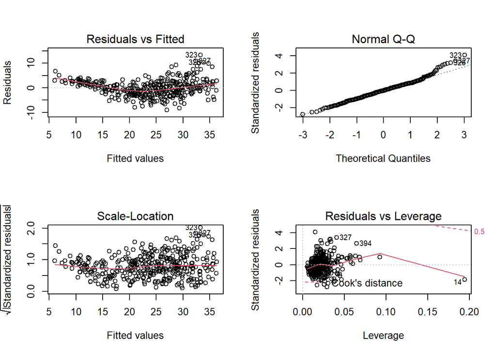

```r
# your code here
par(mfrow=c(2,2))
plot(lm4)
```

```r
df[c(320,323,327,394),]
```

|  | mpg | cylinders | displacement | horsepower | weight | acceleration | year | origin | name |
| --- | --- | --- | --- | --- | --- | --- | --- | --- | --- |
| 322 | 32.2 | 4 | 108 | 75 | 2265 | 15.2 | 80 | Japanese | toyota corolla |
| 325 | 40.8 | 4 | 85 | 65 | 2110 | 19.2 | 80 | Japanese | datsun 210 |
| 329 | 30.0 | 4 | 146 | 67 | 3250 | 21.8 | 80 | European | mercedes-benz 240d |
| NA | NA | NA | NA | NA | NA | NA | NA | NA | NA |

## Step 5: Create and evaluate a fourth model

- Use the * and + symbols to fit linear regression models with interaction effects, choosing whatever variables you think might get better results than your model in step 3 above
- Compare the summaries of the two models, particularly R^2
- Run anova() on the two models to see if your second model outperformed the previous one, and comment below on the results

Your commentary here: My model(lm5) outperformed the previous model(lm4). The R^2 of my model(lm5) was .8807 compared to the previous models’ .8242. The results of anova also show a smaller Res.df and RSS.

```r
# your code here
lm5 <- lm(mpg~(weight+year+origin+displacement+weight*year*origin*displacement), data=df)
summary(lm5)
```

```
##
## Call:
## lm(formula = mpg ~ (weight + year + origin + displacement + weight *
##     year * origin * displacement), data = df)
##
## Residuals:
##     Min      1Q  Median      3Q     Max
## -8.3209 -1.5571  0.0617  1.3664 13.5827
##
## Coefficients:
##                                           Estimate Std. Error t value Pr(>|t|)
## (Intercept)                             -1.584e+02  4.868e+01  -3.255 0.001239
## weight                                   4.849e-02  1.878e-02   2.582 0.010222
## year                                     2.785e+00  6.439e-01   4.326 1.96e-05
## originEuropean                          -7.526e+02  3.061e+02  -2.459 0.014407
## originJapanese                           1.315e+02  2.138e+02   0.615 0.538946
## displacement                             2.857e-01  2.241e-01   1.275 0.203066
## weight:year                             -7.721e-04  2.500e-04  -3.088 0.002169
## weight:originEuropean                    2.124e-01  1.274e-01   1.667 0.096390
## weight:originJapanese                   -1.148e-01  9.217e-02  -1.246 0.213595
## year:originEuropean                      9.880e+00  4.027e+00   2.453 0.014614
## year:originJapanese                     -1.661e+00  2.794e+00  -0.595 0.552463
## weight:displacement                     -1.124e-04  6.114e-05  -1.839 0.066712
## year:displacement                       -4.581e-03  3.029e-03  -1.512 0.131285
## originEuropean:displacement              9.759e+00  2.846e+00   3.428 0.000676
## originJapanese:displacement              2.250e+00  2.362e+00   0.953 0.341432
## weight:year:originEuropean              -2.672e-03  1.662e-03  -1.607 0.108853
## weight:year:originJapanese               1.432e-03  1.202e-03   1.192 0.234210
## weight:year:displacement                 1.722e-06  8.222e-07   2.094 0.036956
## weight:originEuropean:displacement      -3.163e-03  1.081e-03  -2.924 0.003664
## weight:originJapanese:displacement      -4.528e-04  8.901e-04  -0.509 0.611231
## year:originEuropean:displacement        -1.300e-01  3.767e-02  -3.451 0.000623
## year:originJapanese:displacement        -2.796e-02  3.067e-02  -0.911 0.362682
## weight:year:originEuropean:displacement  4.130e-05  1.415e-05   2.919 0.003728
## weight:year:originJapanese:displacement  5.723e-06  1.153e-05   0.496 0.619993
##
## (Intercept)                             **
## weight                                  *
## year                                    ***
## originEuropean                          *
```

[output cut: 11 more lines]

```
## weight:year:originEuropean
## weight:year:originJapanese
## weight:year:displacement                *
## weight:originEuropean:displacement      **
## weight:originJapanese:displacement
## year:originEuropean:displacement        ***
## year:originJapanese:displacement
## weight:year:originEuropean:displacement **
## weight:year:originJapanese:displacement
## ---
## Signif. codes:  0 '***' 0.001 '**' 0.01 '*' 0.05 '.' 0.1 ' ' 1
##
## Residual standard error: 2.779 on 368 degrees of freedom
## Multiple R-squared:  0.8807, Adjusted R-squared:  0.8733
## F-statistic: 118.1 on 23 and 368 DF,  p-value: < 2.2e-16
```

```r
summary(lm4)
```

```
##
## Call:
## lm(formula = mpg ~ (cylinders + displacement + horsepower + weight +
##     acceleration + year + origin), data = df)
##
## Residuals:
##     Min      1Q  Median      3Q     Max
## -9.0095 -2.0785 -0.0982  1.9856 13.3608
##
## Coefficients:
##                  Estimate Std. Error t value Pr(>|t|)
## (Intercept)    -1.795e+01  4.677e+00  -3.839 0.000145 ***
## cylinders      -4.897e-01  3.212e-01  -1.524 0.128215
## displacement    2.398e-02  7.653e-03   3.133 0.001863 **
## horsepower     -1.818e-02  1.371e-02  -1.326 0.185488
## weight         -6.710e-03  6.551e-04 -10.243  < 2e-16 ***
## acceleration    7.910e-02  9.822e-02   0.805 0.421101
## year            7.770e-01  5.178e-02  15.005  < 2e-16 ***
## originEuropean  2.630e+00  5.664e-01   4.643 4.72e-06 ***
## originJapanese  2.853e+00  5.527e-01   5.162 3.93e-07 ***
## ---
## Signif. codes:  0 '***' 0.001 '**' 0.01 '*' 0.05 '.' 0.1 ' ' 1
##
## Residual standard error: 3.307 on 383 degrees of freedom
## Multiple R-squared:  0.8242, Adjusted R-squared:  0.8205
## F-statistic: 224.5 on 8 and 383 DF,  p-value: < 2.2e-16
```

```r
anova(lm5,lm4)
```

|  | Res.Df | RSS | Df | Sum of Sq | F | Pr(>F) |
| --- | --- | --- | --- | --- | --- | --- |
| 1 | 368 | 2841.104 | NA | NA | NA | NA |
| 2 | 383 | 4187.392 | -15 | -1346.288 | 11.62539 | 2.186747e-23 |